# Avaliação Risco de Empréstimo Bancário

Marcio Cruz

10/07/2021

## Case

Considere dados históricos provenientes de um banco de varejo, referentes a 5.000 propostas de crédito geradas durante solicitações de empréstimo. A base traz informações como idade, nível de instrução, tempo de experiência, tempo no endereço e renda; além da variável resposta “classif” (0=bom pagador, 1=mau pagador). Deseja-se avaliar o potencial dessas variáveis para predizer se um cliente será um bom ou mau pagador.

## a) Faça a análise exploratória univariada e interprete todas as variáveis do banco de dados.

```
##      idade        experiencia     tempo_endereco       renda
##  Min.   :20.00   Min.   : 0.000   Min.   : 0.000   Min.   :  12.10
##  1st Qu.:29.00   1st Qu.: 3.000   1st Qu.: 3.000   1st Qu.:  24.50
##  Median :35.00   Median : 7.000   Median : 7.000   Median :  34.50
##  Mean   :35.39   Mean   : 8.704   Mean   : 8.154   Mean   :  47.68
##  3rd Qu.:41.00   3rd Qu.:13.000   3rd Qu.:12.000   3rd Qu.:  54.73
##  Max.   :58.00   Max.   :38.000   Max.   :37.000   Max.   :2461.70
##   debito_renda       cred_deb         outros_debitos        classif
##  Min.   : 0.080   Min.   :  0.00529   Min.   :  0.0094   Min.   :0.0000
##  1st Qu.: 5.050   1st Qu.:  0.39618   1st Qu.:  0.9901   1st Qu.:0.0000
##  Median : 8.635   Median :  0.90619   Median :  1.9602   Median :0.0000
##  Mean   :10.076   Mean   :  1.62807   Mean   :  3.2186   Mean   :0.2512
##  3rd Qu.:13.682   3rd Qu.:  1.85915   3rd Qu.:  3.7896   3rd Qu.:1.0000
##  Max.   :44.620   Max.   :139.58061   Max.   :416.5174   Max.   :1.0000
```

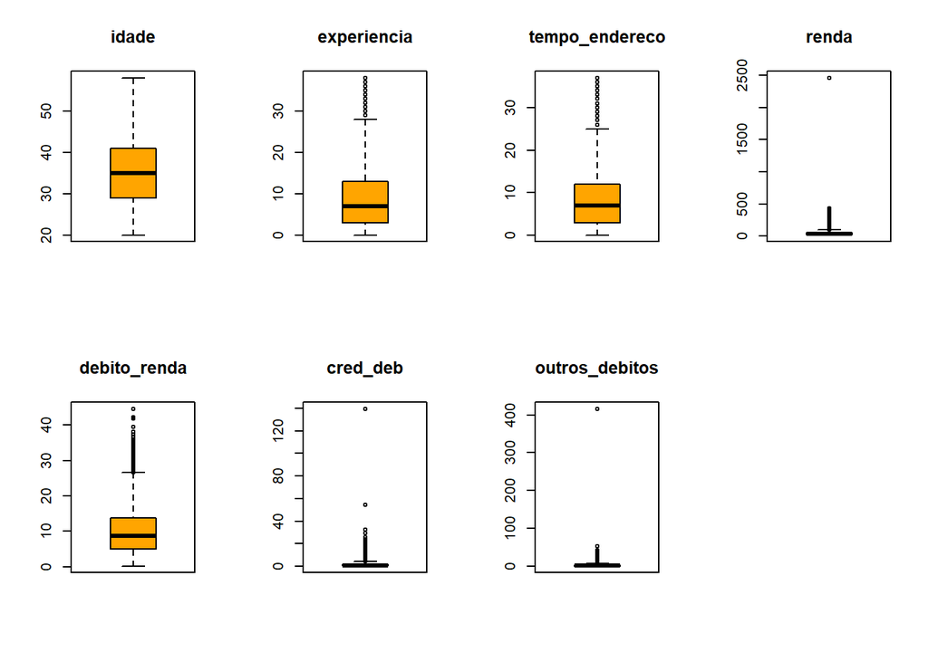

Todas as variáveis são quantitativas contínuas e, analisando graficamente apenas a idade não apresenta outlier. Podemos observar também que valores monetários possuem uma amplitude muito alta, que indica fortemente que a outlieres a maior destes números.

## b) Há algum outlier que mereça atenção? E com relação a dados faltantes?

### Primeira Análise

Análise Inicial do Banco

|  | variavel | li | ls | missing | outlier_menor | outlier_maior |
| --- | --- | --- | --- | --- | --- | --- |
| 25% | idade | 11.000000 | 59.000000 | 0 | 0 | 0 |
| 25%1 | experiencia | -12.000000 | 28.000000 | 0 | 0 | 72 |
| 25%2 | tempo_endereco | -10.500000 | 25.500000 | 0 | 0 | 95 |
| 25%3 | renda | -20.837500 | 100.062500 | 0 | 0 | 392 |
| 25%4 | debito_renda | -7.898750 | 26.631250 | 0 | 0 | 125 |
| 25%5 | cred_deb | -1.798268 | 4.053596 | 0 | 0 | 404 |
| 25%6 | outros_debitos | -3.209273 | 7.988976 | 0 | 0 | 395 |

#### Missing:

Nenhuma variável nesta situação

#### Visão sobre os Outlier:

##### Experiêcia e Tempo endereço: possuem valores discrepantes do ponto de vista estatístico mas, analisando o boxplot e os valores descritivos, concluo que são normais do ponto de vista de negócio.

##### Variáveis explicativas monetárias: Todas apresentam outlier mas, começaremos a análise pela Renda, até não ter mais outlier desta variável.

#### Outlier de Renda:

Retirado os outliers de Renda em 9 passo(s). Observações a serem analisadas: 4230

|  | variavel | li | ls | missing | outlier_menor | outlier_maior |
| --- | --- | --- | --- | --- | --- | --- |
| 25% | idade | 11.500000 | 55.500000 | 0 | 0 | 6 |
| 25%1 | experiencia | -10.000000 | 22.000000 | 0 | 0 | 33 |
| 25%2 | tempo_endereco | -9.000000 | 23.000000 | 0 | 0 | 85 |
| 25%3 | renda | -5.837500 | 71.662500 | 0 | 0 | 0 |
| 25%4 | debito_renda | -7.890000 | 26.590000 | 0 | 0 | 104 |
| 25%5 | cred_deb | -1.379138 | 3.225891 | 0 | 0 | 267 |
| 25%6 | outros_debitos | -2.305346 | 6.220827 | 0 | 0 | 204 |

```
##      idade        experiencia     tempo_endereco      renda
##  Min.   :20.00   Min.   : 0.000   Min.   : 0.00   Min.   :12.10
##  1st Qu.:28.00   1st Qu.: 2.000   1st Qu.: 3.00   1st Qu.:23.23
##  Median :33.00   Median : 6.000   Median : 6.00   Median :31.05
##  Mean   :33.98   Mean   : 6.943   Mean   : 7.48   Mean   :34.23
##  3rd Qu.:39.00   3rd Qu.:10.000   3rd Qu.:11.00   3rd Qu.:42.60
##  Max.   :57.00   Max.   :30.000   Max.   :37.00   Max.   :71.60
##   debito_renda       cred_deb         outros_debitos         classif
##  Min.   : 0.080   Min.   : 0.005292   Min.   : 0.009373   Min.   :0.0000
##  1st Qu.: 5.040   1st Qu.: 0.347748   1st Qu.: 0.891969   1st Qu.:0.0000
##  Median : 8.595   Median : 0.773926   Median : 1.679545   Median :0.0000
##  Mean   :10.040   Mean   : 1.155030   Mean   : 2.264921   Mean   :0.2619
##  3rd Qu.:13.660   3rd Qu.: 1.499005   3rd Qu.: 3.023512   3rd Qu.:1.0000
##  Max.   :44.620   Max.   :12.355391   Max.   :16.472804   Max.   :1.0000
```

Na análise inicial, identificou-se que há 392 registros que possuem renda anual em salário mínimos discrepantes.

## c) Qual o % de empréstimos não pagos (ou “% de maus”, ou “% de default”)?

O percentual de bons pagadores é 73.8061%, em contrapartida, há 26.1939% de maus pagadores.

## d) Qual a correlação entre as variáveis presentes na base?

Variáveis que não podem estar no mesmo modelo devido a multicolinearidade

|  | idade | experiencia | tempo_endereco | renda | debito_renda | cred_deb | outros_debitos |
| --- | --- | --- | --- | --- | --- | --- | --- |
| idade | 1.0000000 | 0.3866605 | 0.5896718 | 0.4324771 | -0.0237574 | 0.1521288 | 0.1826542 |
| experiencia | 0.3866605 | 1.0000000 | 0.2171501 | 0.5879068 | -0.0262845 | 0.1964029 | 0.2529922 |
| tempo_endereco | 0.5896718 | 0.2171501 | 1.0000000 | 0.2386801 | -0.0232403 | 0.0726954 | 0.0951698 |
| renda | 0.4324771 | 0.5879068 | 0.2386801 | 1.0000000 | -0.0177139 | 0.3744082 | 0.4501370 |
| debito_renda | -0.0237574 | -0.0262845 | -0.0232403 | -0.0177139 | 1.0000000 | 0.6209465 | 0.7328457 |
| cred_deb | 0.1521288 | 0.1964029 | 0.0726954 | 0.3744082 | 0.6209465 | 1.0000000 | 0.4594946 |
| outros_debitos | 0.1826542 | 0.2529922 | 0.0951698 | 0.4501370 | 0.7328457 | 0.4594946 | 1.0000000 |

| variavel1 | variavel2 | correlacao |
| --- | --- | --- |
| debito_renda | outros_debitos | 0.7328457 |

### e) Quais são as variáveis que melhor explicam se o empréstimo foi pago ou não?

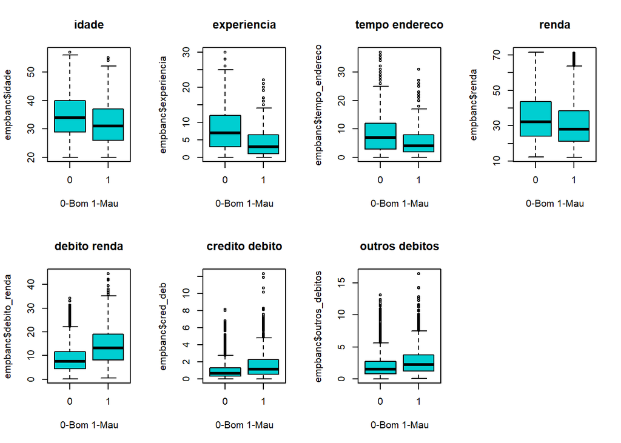

De acordo com a análise gráfica, quem é mais velho, quem tem maior tempo de experiência, maior tempo de endereço, renda maior são fatores que influenciam um cliente ser um bom pagador. Porém, se o cliente possuir outros débitos, se a razão o que ele ganha e gasta for alta, influencia a ser um mau pagador.

### f) Ajuste um modelo logístico e avalie quais variáveis apareceram como significantes. Adote 10% de significância.

#### Abordagem com a variável relação débito e renda total

```
##
## Call:
## glm(formula = classif ~ idade + experiencia + tempo_endereco +
##     renda + cred_deb + debito_renda, family = binomial(link = "logit"),
##     data = empbanc)
##
## Deviance Residuals:
##     Min       1Q   Median       3Q      Max
## -2.1742  -0.7027  -0.3986   0.4626   3.0294
##
## Coefficients:
##                 Estimate Std. Error z value             Pr(>|z|)
## (Intercept)    -1.246725   0.222122  -5.613  0.00000001990866066 ***
## idade           0.003417   0.007316   0.467                0.640
## experiencia    -0.197549   0.011556 -17.095 < 0.0000000000000002 ***
## tempo_endereco -0.095609   0.009466 -10.100 < 0.0000000000000002 ***
## renda           0.007597   0.004267   1.781                0.075 .
## cred_deb        0.385235   0.049655   7.758  0.00000000000000862 ***
## debito_renda    0.102922   0.008129  12.662 < 0.0000000000000002 ***
## ---
## Signif. codes:  0 '***' 0.001 '**' 0.01 '*' 0.05 '.' 0.1 ' ' 1
##
## (Dispersion parameter for binomial family taken to be 1)
##
##     Null deviance: 4865.1  on 4229  degrees of freedom
## Residual deviance: 3681.1  on 4223  degrees of freedom
## AIC: 3695.1
##
## Number of Fisher Scoring iterations: 5
```

```
##
## Call:
## glm(formula = classif ~ experiencia + tempo_endereco + renda +
##     cred_deb + debito_renda, family = binomial(link = "logit"),
##     data = empbanc)
##
## Deviance Residuals:
##     Min       1Q   Median       3Q      Max
## -2.1761  -0.7015  -0.3975   0.4655   3.0231
##
## Coefficients:
##                 Estimate Std. Error z value             Pr(>|z|)
## (Intercept)    -1.167201   0.142371  -8.198 0.000000000000000244 ***
## experiencia    -0.196849   0.011457 -17.181 < 0.0000000000000002 ***
## tempo_endereco -0.093389   0.008188 -11.405 < 0.0000000000000002 ***
## renda           0.008058   0.004150   1.942               0.0522 .
## cred_deb        0.384696   0.049652   7.748 0.000000000000009348 ***
## debito_renda    0.102953   0.008131  12.662 < 0.0000000000000002 ***
## ---
## Signif. codes:  0 '***' 0.001 '**' 0.01 '*' 0.05 '.' 0.1 ' ' 1
##
## (Dispersion parameter for binomial family taken to be 1)
##
##     Null deviance: 4865.1  on 4229  degrees of freedom
## Residual deviance: 3681.3  on 4224  degrees of freedom
## AIC: 3693.3
##
## Number of Fisher Scoring iterations: 5
```

```
##
## Call:
## glm(formula = classif ~ experiencia + tempo_endereco + cred_deb +
##     debito_renda, family = binomial(link = "logit"), data = empbanc)
##
## Deviance Residuals:
##     Min       1Q   Median       3Q      Max
## -2.1599  -0.7057  -0.3990   0.4577   3.0155
##
## Coefficients:
##                 Estimate Std. Error z value            Pr(>|z|)
## (Intercept)    -0.965529   0.096625  -9.993 <0.0000000000000002 ***
## experiencia    -0.188398   0.010566 -17.831 <0.0000000000000002 ***
## tempo_endereco -0.091542   0.008126 -11.265 <0.0000000000000002 ***
## cred_deb        0.428300   0.044548   9.614 <0.0000000000000002 ***
## debito_renda    0.098058   0.007714  12.712 <0.0000000000000002 ***
## ---
## Signif. codes:  0 '***' 0.001 '**' 0.01 '*' 0.05 '.' 0.1 ' ' 1
##
## (Dispersion parameter for binomial family taken to be 1)
##
##     Null deviance: 4865.1  on 4229  degrees of freedom
## Residual deviance: 3685.1  on 4225  degrees of freedom
## AIC: 3695.1
##
## Number of Fisher Scoring iterations: 5
```

#### Abordagem com a variável outros débitos

```
##
## Call:
## glm(formula = classif ~ idade + experiencia + tempo_endereco +
##     renda + cred_deb + outros_debitos, family = binomial(link = "logit"),
##     data = empbanc)
##
## Deviance Residuals:
##     Min       1Q   Median       3Q      Max
## -2.4499  -0.7229  -0.4013   0.4746   3.1917
##
## Coefficients:
##                 Estimate Std. Error z value             Pr(>|z|)
## (Intercept)    -0.113060   0.202623  -0.558                0.577
## idade           0.004882   0.007282   0.670                0.503
## experiencia    -0.201243   0.011705 -17.192 < 0.0000000000000002 ***
## tempo_endereco -0.096544   0.009489 -10.174 < 0.0000000000000002 ***
## renda          -0.025278   0.004446  -5.686          0.000000013 ***
## cred_deb        0.681571   0.041690  16.349 < 0.0000000000000002 ***
## outros_debitos  0.283058   0.025304  11.186 < 0.0000000000000002 ***
## ---
## Signif. codes:  0 '***' 0.001 '**' 0.01 '*' 0.05 '.' 0.1 ' ' 1
##
## (Dispersion parameter for binomial family taken to be 1)
##
##     Null deviance: 4865.1  on 4229  degrees of freedom
## Residual deviance: 3720.6  on 4223  degrees of freedom
## AIC: 3734.6
##
## Number of Fisher Scoring iterations: 5
```

```
##
## Call:
## glm(formula = classif ~ experiencia + tempo_endereco + renda +
##     cred_deb + outros_debitos, family = binomial(link = "logit"),
##     data = empbanc)
##
## Deviance Residuals:
##     Min       1Q   Median       3Q      Max
## -2.4653  -0.7229  -0.3996   0.4751   3.1764
##
## Coefficients:
##                  Estimate Std. Error z value             Pr(>|z|)
## (Intercept)     0.0005359  0.1110279   0.005                0.996
## experiencia    -0.2002453  0.0116080 -17.251 < 0.0000000000000002 ***
## tempo_endereco -0.0933101  0.0081731 -11.417 < 0.0000000000000002 ***
## renda          -0.0246032  0.0043260  -5.687         0.0000000129 ***
## cred_deb        0.6809941  0.0416882  16.335 < 0.0000000000000002 ***
## outros_debitos  0.2828184  0.0253058  11.176 < 0.0000000000000002 ***
## ---
## Signif. codes:  0 '***' 0.001 '**' 0.01 '*' 0.05 '.' 0.1 ' ' 1
##
## (Dispersion parameter for binomial family taken to be 1)
##
##     Null deviance: 4865.1  on 4229  degrees of freedom
## Residual deviance: 3721.0  on 4224  degrees of freedom
## AIC: 3733
##
## Number of Fisher Scoring iterations: 5
```

### g) Calcule o score de propensão a default como uma coluna nova na base.

Score de propensão

| idade | experiencia | tempo_endereco | renda | debito_renda | cred_deb | outros_debitos | classif | score_propensao |
| --- | --- | --- | --- | --- | --- | --- | --- | --- |
| 41 | 17 | 12 | 35.9 | 11.90 | 0.5041078 | 3.7679922 | 0 | 0.0201537 |
| 30 | 13 | 8 | 46.7 | 17.88 | 1.3526935 | 6.9972665 | 0 | 0.1401063 |
| 40 | 15 | 14 | 61.8 | 10.64 | 3.4389970 | 3.1365230 | 0 | 0.0719685 |
| 57 | 7 | 37 | 25.6 | 15.86 | 1.4981990 | 2.5619610 | 0 | 0.0300463 |
| 45 | 0 | 13 | 28.1 | 4.28 | 0.9248609 | 0.2778191 | 0 | 0.2075471 |
| 36 | 1 | 3 | 19.6 | 12.82 | 1.2111310 | 1.3015890 | 1 | 0.5859572 |

### h) Qual a sugestão inicial de ponto de corte para predizer se o empréstimo será pago ou não?

```r
empbanc$predito <- as.factor(ifelse(empbanc$score_propensao > 0.5, 1, 0))
```

O valor inicial foi 50%.

### i) Considerando essa sugestão, construa a matriz de confusão. Qual a taxa de classificação correta?

Resposta Observada x Resposta Predita

|  | 0 | 1 |
| --- | --- | --- |
| 0 | 2897 | 225 |
| 1 | 654 | 454 |

#### Diagonais:

##### Diagonal Principal:3351.0000

##### Diagonal Secundária:879.0000

##### Proporção: 3.8123

#### Índices:

##### Acurácia (vp+vn / vp+vn+fp+fn): 0.7922

##### Sensibilidade (vp/vp+fn): 0.4097

##### Especificidade (vn/vn+fp): 0.9279

### Interpretação sobre o modelo

#### Apresenta bom ajuste, já que há concentração dos casos na diagonal principal, confirmado pela acurácia de: 79.22%

#### Sendo que o objetivo do modelo é descobrir quem seja um mau pagador, usaremos a referência do indicador de sensibilidade: 40.97%. 654 classificados com mau pagadores, foram classificados incorretamente e, 454 classificados como mau pagadores, foram classificados corretamente.

#### O resultado do índice de sensibilidade demonstra um ajuste regular do modelo.